# Actividad 2.8 Regresión Logística

Rey Iván De La Fuente Chávez

2026-09-05

## 1. División de los datos

Se utiliza el conjunto `Weekly` del paquete `ISLR`. Las observaciones de 1990 a 2008 se utilizan para entrenar el modelo y las de 2009 y 2010 para evaluarlo.

```r
library(ISLR)
data(Weekly)

entrenamiento <- subset(Weekly, Year <= 2008)
prueba <- subset(Weekly, Year >= 2009)

dim(entrenamiento)
```

```
## [1] 985   9
```

```r
dim(prueba)
```

```
## [1] 104   9
```

El conjunto de entrenamiento contiene **985 observaciones**, mientras que el conjunto de prueba contiene **104 observaciones**.

## 2. Modelo de regresión logística

Se ajusta un modelo para predecir si el rendimiento semanal será positivo (`Up`) o negativo (`Down`) utilizando únicamente `Lag2`.

```r
modelo <- glm(Direction ~ Lag2,
              data = entrenamiento,
              family = binomial)

summary(modelo)
```

```
##
## Call:
## glm(formula = Direction ~ Lag2, family = binomial, data = entrenamiento)
##
## Coefficients:
##             Estimate Std. Error z value Pr(>|z|)
## (Intercept)  0.20326    0.06428   3.162  0.00157 **
## Lag2         0.05810    0.02870   2.024  0.04298 *
## ---
## Signif. codes:  0 '***' 0.001 '**' 0.01 '*' 0.05 '.' 0.1 ' ' 1
##
## (Dispersion parameter for binomial family taken to be 1)
##
##     Null deviance: 1354.7  on 984  degrees of freedom
## Residual deviance: 1350.5  on 983  degrees of freedom
## AIC: 1354.5
##
## Number of Fisher Scoring iterations: 4
```

El coeficiente de `Lag2` es positivo, por lo que un mayor rendimiento dos semanas atrás se relaciona con una mayor probabilidad de que el mercado actual tenga dirección `Up`.

## 3. Ecuación del modelo

El modelo obtenido es:

$$\log\left(\frac{p}{1-p}\right)
=0.2033+0.0581Lag2$$

y la probabilidad de que `Direction = Up` es:

$$p=
\frac{e^{0.2033+0.0581Lag2}}
{1+e^{0.2033+0.0581Lag2}}$$

```r
beta0 <- coef(modelo)[1]
beta1 <- coef(modelo)[2]

cat("Beta 0 =", round(beta0, 4), "\n")
```

```
## Beta 0 = 0.2033
```

```r
cat("Beta 1 =", round(beta1, 4), "\n")
```

```
## Beta 1 = 0.0581
```

## 4. Interpretación de Lag2

El p-value de `Lag2` es **0.043**, menor que 0.05. Por lo tanto, `Lag2` es **estadísticamente significativo** para explicar la dirección del mercado.

Por cada unidad que aumenta `Lag2`, el logaritmo de los odds de que el mercado sea `Up` aumenta en **0.0581 unidades**.

```r
odds_ratio <- exp(beta1)
odds_ratio
```

```
##     Lag2
## 1.059816
```

Los odds se multiplican por **1.0598**, es decir, aumentan aproximadamente **5.98% por cada unidad adicional de Lag2**.

Como ejemplo, para `Lag2 = 1`:

```r
predict(modelo,
        newdata = data.frame(Lag2 = 1),
        type = "response")
```

```
##         1
## 0.5649688
```

La probabilidad estimada de que el mercado sea `Up` cuando `Lag2 = 1` es aproximadamente **56.5%**.

## 5. Representación gráfica

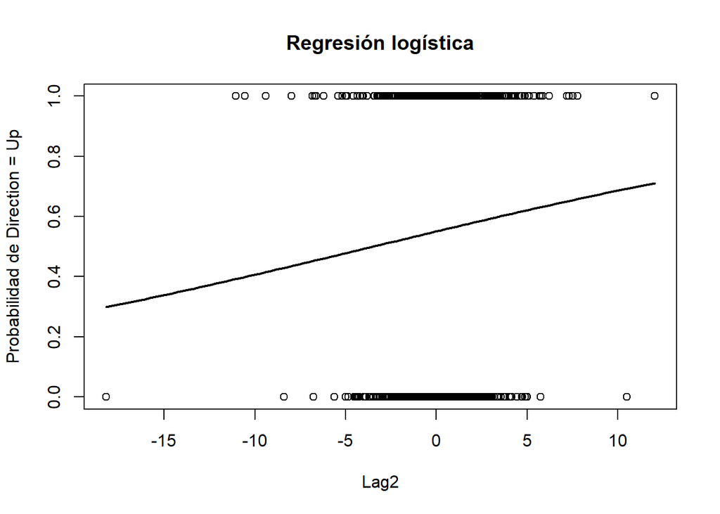

```r
plot(entrenamiento$Lag2,
     as.numeric(entrenamiento$Direction == "Up"),
     xlab = "Lag2",
     ylab = "Probabilidad de Direction = Up",
     main = "Regresión logística")

curve(predict(modelo,
              newdata = data.frame(Lag2 = x),
              type = "response"),
      add = TRUE,
      lwd = 2)
```

La curva presenta una pendiente ligeramente positiva. Esto concuerda con el coeficiente de `Lag2`: conforme aumenta `Lag2`, aumenta la probabilidad estimada de que el mercado sea `Up`, aunque el efecto es pequeño.

## 6. Evaluación del modelo

### Análisis de Deviance

```r
modelo_nulo <- glm(Direction ~ 1,
                   data = entrenamiento,
                   family = binomial)

anova(modelo_nulo, modelo, test = "Chisq")
```

```
## Analysis of Deviance Table
##
## Model 1: Direction ~ 1
## Model 2: Direction ~ Lag2
##   Resid. Df Resid. Dev Df Deviance Pr(>Chi)
## 1       984     1354.7
## 2       983     1350.5  1   4.1666  0.04123 *
## ---
## Signif. codes:  0 '***' 0.001 '**' 0.01 '*' 0.05 '.' 0.1 ' ' 1
```

El p-value de la prueba es **0.0412**, menor que 0.05. Por lo tanto, incluir `Lag2` mejora significativamente al modelo que no utiliza ningún predictor.

### Predicciones

```r
probabilidades <- predict(modelo,
                          newdata = prueba,
                          type = "response")

prediccion <- ifelse(probabilidades > 0.5, "Up", "Down")

prediccion <- factor(prediccion,
                     levels = levels(prueba$Direction))
```

### Tabla de contingencia

```r
tabla <- table(Real = prueba$Direction,
               Predicho = prediccion)

tabla
```

```
##       Predicho
## Real   Down Up
##   Down    9 34
##   Up      5 56
```

El modelo clasificó correctamente **9 semanas Down** y **56 semanas Up**. Sin embargo, clasificó incorrectamente como `Up` a 34 semanas que realmente fueron `Down`, mostrando mayor dificultad para detectar mercados a la baja.

### Diagrama de mosaico

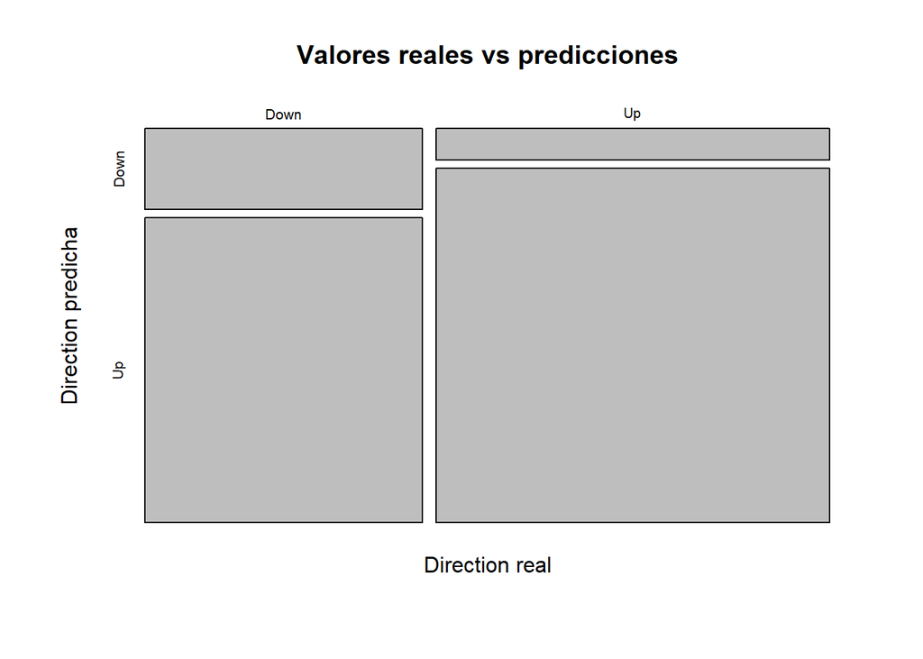

```r
mosaicplot(tabla,
           main = "Valores reales vs predicciones",
           xlab = "Direction real",
           ylab = "Direction predicha")
```

El diagrama confirma que el modelo tiende a clasificar con mayor frecuencia las observaciones como `Up`.

### Métricas

```r
exactitud <- sum(diag(tabla)) / sum(tabla)
error <- 1 - exactitud

sensibilidad <- tabla["Up", "Up"] /
  sum(tabla["Up", ])

especificidad <- tabla["Down", "Down"] /
  sum(tabla["Down", ])

metricas <- c(
  Exactitud = exactitud,
  Error = error,
  Sensibilidad = sensibilidad,
  Especificidad = especificidad
) * 100

round(metricas, 2)
```

```
##     Exactitud         Error  Sensibilidad Especificidad
##         62.50         37.50         91.80         20.93
```

La **exactitud es 62.5%**, por lo que el modelo clasifica correctamente aproximadamente 6 de cada 10 semanas.

La **tasa de error es 37.5%**.

La **sensibilidad es 91.8%**, por lo que el modelo identifica muy bien las semanas en las que el mercado realmente sube.

La **especificidad es 20.93%**, indicando que el modelo tiene dificultades para identificar correctamente las semanas en las que el mercado baja.

En general, el modelo funciona mucho mejor para detectar mercados `Up` que mercados `Down`.

## 7. Validación de supuestos

### Independencia

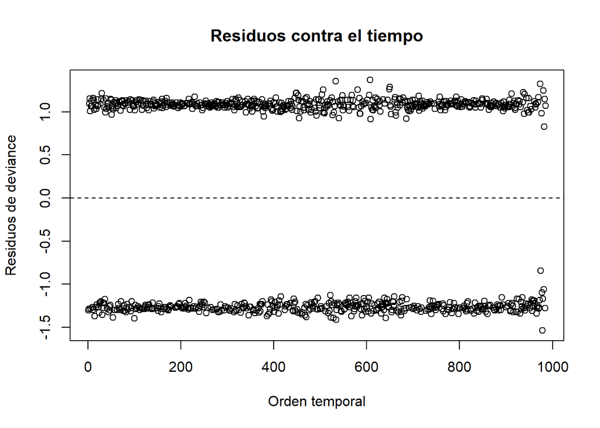

```r
residuos <- residuals(modelo, type = "deviance")
tiempo <- seq_along(residuos)

plot(tiempo, residuos,
     xlab = "Orden temporal",
     ylab = "Residuos de deviance",
     main = "Residuos contra el tiempo")

abline(h = 0, lty = 2)
```

No se aprecia un patrón temporal fuerte en los residuos, lo cual favorece el supuesto de independencia.

```r
lmtest::dwtest(residuos ~ tiempo)
```

```
##
##  Durbin-Watson test
##
## data:  residuos ~ tiempo
## DW = 2.1595, p-value = 0.9933
## alternative hypothesis: true autocorrelation is greater than 0
```

El estadístico Durbin-Watson es **2.1595** y el p-value es **0.9933**. Al estar el estadístico cerca de 2 y no ser significativa la prueba, no se encuentra evidencia de autocorrelación positiva en los residuos.

### Multicolinealidad

No es necesario calcular VIF porque el modelo contiene solamente un predictor (`Lag2`), por lo que no puede existir multicolinealidad entre variables predictoras.

### Linealidad con el logit

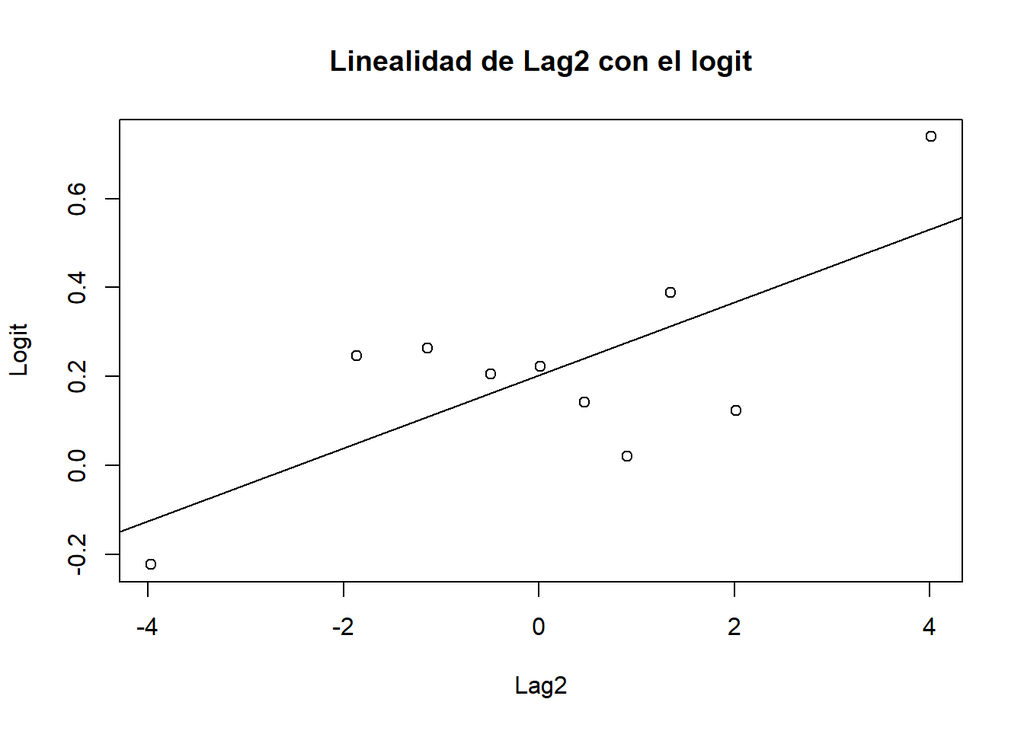

```r
entrenamiento$Up <- ifelse(entrenamiento$Direction == "Up", 1, 0)

grupos <- cut(
  entrenamiento$Lag2,
  breaks = unique(quantile(entrenamiento$Lag2,
                           probs = seq(0, 1, 0.1))),
  include.lowest = TRUE
)

linealidad <- aggregate(
  cbind(Lag2, Up) ~ grupos,
  data = entrenamiento,
  FUN = mean
)

linealidad$logit <- qlogis(linealidad$Up)

plot(linealidad$Lag2,
     linealidad$logit,
     xlab = "Lag2",
     ylab = "Logit",
     main = "Linealidad de Lag2 con el logit")

abline(lm(logit ~ Lag2, data = linealidad))
```

La gráfica permite observar una relación aproximadamente lineal entre `Lag2` y el logit, por lo que visualmente no se observa una violación importante de este supuesto.

### Prueba de Box-Tidwell

```r
entrenamiento$Lag2_pos <- entrenamiento$Lag2 -
  min(entrenamiento$Lag2) + 0.001

car::boxTidwell(Up ~ Lag2_pos,
                data = entrenamiento)
```

```
##  MLE of lambda Score Statistic (t) Pr(>|t|)
##         3.9404              0.5259   0.5991
##
## iterations =  20
```

La prueba obtiene un p-value de **0.5991**, mayor que 0.05. Por lo tanto, no existe evidencia para rechazar el supuesto de linealidad entre el predictor y el logit.

### Tamaño de muestra

```r
table(entrenamiento$Direction)
```

```
##
## Down   Up
##  441  544
```

Existen **441 observaciones Down y 544 Up**. La categoría menos frecuente tiene mucho más de 10 observaciones, por lo que se cumple ampliamente el requisito de tamaño de muestra.

## Conclusión

`Lag2` es un predictor estadísticamente significativo de la dirección semanal del mercado. Sin embargo, el modelo tiene una capacidad predictiva moderada, con una exactitud de **62.5%**. Su principal limitación es que identifica muy bien las semanas `Up`, pero tiene dificultades para reconocer las semanas `Down`. Los supuestos evaluados no muestran problemas importantes.